# The Python Data Science Stack

### Dr. Florian Wilhelm

#### Senior Professional: Data Scientist @ CSC

# What is Python?

- multi-purpose
- focused on readability and productivity
- easy to learn
- object oriented
- interpreted
- strongely and dynamically typed
- cross platform

# Features

- indentation is part of the syntax
- high level data types (tuples, lists, dictionaries, sets)
- Python Standard Library (Batteries included)
  - string sevices, regular expressions
  - mathematical modules
  - IO, file formats and data persistence
  - OS, threading, multiprocessing
  - networking, email, html, webserver
  - ...
- easily extensible with C/C++ (glue language)
- tons of external libraries

# Why Python for Analytics?

Besides the features already mentioned, Python has:

- large communities for data science, analytics, visualisation etc.,
- many and well-established libraries,
- lots of examples and documentation,
- **huge** demand from the industry.

[figure not shown]

# Python 2 vs. 3

[figure not shown]

Source: [LearnToCodeWithMe](http://learntocodewith.me/programming/python/python-2-vs-python-3/)

## Use Python 3! All relevant libraries are ported!

# Installation

### Linux & Mac

[figure not shown]

*It is already installed!* Use [virtualenv](http://virtualenv.readthedocs.org/) and [pip](https://pip.pypa.io/) to setup isolated environments and install more packages. [Conda](http://conda.pydata.org/docs/) is an alternative.

### Windows

[figure not shown]

*A bit trickier!* Best use the [Anaconda distribution](https://www.continuum.io/downloads) from Continuum Analytics to install everything you need to get going.

# Primer on Python

Strong and dynamically typed

```python
x = 23
3*x
```

```
69
```

```python
x = "Hello "
y = "World!"
print(x + y)
```

```
Hello World!
```

```python
print(x + 1)
```

```
---------------------------------------------------------------------------
TypeError                                 Traceback (most recent call last)
<ipython-input-4-17ee3e2a0896> in <module>()
----> 1 print(x + 1)

TypeError: Can't convert 'int' object to str implicitly
```

## Indentation matters!

```python
x = 3

if x > 0:
    if x % 2 == 0:
        print("Positive, even number!")
    else:
        print("Positive, odd number!")
else:
    print("Non-positive number!")
```

```
Positive, odd number!
```

```python
def bmi(height, weight):
    return weight / height**2

print("The BMI is: {:.3}".format(bmi(1.85, 79)))
```

```
The BMI is: 23.1
```

## Tuples

```python
x = (1, 3, 5)
print(x)
```

```
(1, 3, 5)
```

```python
x[2]
```

```
5
```

```python
a, b, c = x
print(a + b + c)
```

```
9
```

```python
a, *others = x
print(a, 'and', others)
```

```
1 and [3, 5]
```

## Lists

```python
x = [1, 3, 5]
print(x)
```

```
[1, 3, 5]
```

```python
x.append(7)
print(x)
```

```
[1, 3, 5, 7]
```

```python
del x[0]
print(x)
```

```
[3, 5, 7]
```

## Dictionaries

```python
x = {'a': 1, 'b': 2, 'c': 3}
```

```python
print(x['b'])
```

```
2
```

```python
x['d'] = 4
print(x)
```

```
{'a': 1, 'd': 4, 'b': 2, 'c': 3}
```

```python
x['dispatch'] = lambda x: x + 41
x['dispatch'](1)
```

```
42
```

Powerful and easy to use data structures like lists and dictionaries allow **declarative programming**.

## Loops and list comprehension

```python
x = []
for i in range(5):
    x.append(i**2)
print(x)
```

```
[0, 1, 4, 9, 16]
```

```python
# better
x = [i**2 for i in range(5)]
print(x)
```

```
[0, 1, 4, 9, 16]
```

Many more *high-level* concepts available to express an algorithm as *natural* as possible.

# Python Data Science Stack

[figure not shown]

# Python Data Science Stack

[figure not shown]

# Python Data Science Stack

- **NumPy** to work efficiently with multi-dimensional arrays and matrices. Includes some high-level mathematical operations.
- **SciPy** extends NumPy with additional modules (optimization, linear algebra, integration, interpolation, special functions, FFT, signal and image processing, ODE solvers etc.).
- **Pandas** builds upon NumPy and provides high-performance, easy-to-use data structures and data analysis tools.
- **Scikit-Learn** provides simple and efficient machine learning tools for data mining and data analysis.
- **matplotlib** provides 2d plotting capabilities. Use additionally **Seaborn** for statistical plots.
- **IPython** is a powerful interactive shell and a kernel for *Jupyter*.
- **Jupyter** Notebook is a web application that allows you to create and share documents that contain live code, equations, visualizations and explanatory text.

Many libraries internally use efficient C/C++ and FORTRAN implementations!

# Jupyter/IPython Notebook

[figure not shown]

Live demonstration

# Titanic: Analysis of a Disaster

[figure not shown]

Painting from [Willy Stöwer](https://en.wikipedia.org/wiki/Sinking_of_the_RMS_Titanic), source & more information: [Kaggle](https://www.kaggle.com/c/titanic)

# Can we predict who survived on the Titanic?

Based on the properties of a passenger like:

- gender,
- age,
- passenger class,
- number of siblings,
- ...

## Setting things up and reading in the data

```python
import pandas as pd
import numpy as np
import matplotlib.pyplot as plt
import seaborn as sns
%matplotlib inline

df = pd.read_csv('./input/train.csv')
```

```python
df.head()
```

|  | Alive | Class | Name | Sex | Age | SibSp | Parch | Ticket | Fare | Cabin | Port |
| --- | --- | --- | --- | --- | --- | --- | --- | --- | --- | --- | --- |
| 0 | 0 | 3 | Braund, Mr | male | 22 | 1 | 0 | A/5 21171 | 7.2500 | NaN | S |
| 1 | 1 | 1 | Cumings, M | female | 38 | 1 | 0 | PC 17599 | 71.2833 | C85 | C |
| 2 | 1 | 3 | Heikkinen, | female | 26 | 0 | 0 | STON/O2. 3101282 | 7.9250 | NaN | S |
| 3 | 1 | 1 | Futrelle, | female | 35 | 1 | 0 | 113803 | 53.1000 | C123 | S |
| 4 | 0 | 3 | Allen, Mr. | male | 35 | 0 | 0 | 373450 | 8.0500 | NaN | S |

## Preprocessing

```python
# We drop some hard to use columns and define 'Port', 'Sex' and 'Class' as categories
df = df.drop(['Name', 'Ticket', 'Cabin'], axis=1)
df['Port'] = df['Port'].astype('category')
df['Sex'] = df['Sex'].astype('category')
df['Class'] = df['Class'].astype('category')
df.head()
```

|  | Alive | Class | Sex | Age | SibSp | Parch | Fare | Port |
| --- | --- | --- | --- | --- | --- | --- | --- | --- |
| 0 | 0 | 3 | male | 22 | 1 | 0 | 7.2500 | S |
| 1 | 1 | 1 | female | 38 | 1 | 0 | 71.2833 | C |
| 2 | 1 | 3 | female | 26 | 0 | 0 | 7.9250 | S |
| 3 | 1 | 1 | female | 35 | 1 | 0 | 53.1000 | S |
| 4 | 0 | 3 | male | 35 | 0 | 0 | 8.0500 | S |

```python
df.shape
```

```
(891, 8)
```

## Data cleansing

```python
df.describe()
```

|  | Alive | Age | SibSp | Parch | Fare |
| --- | --- | --- | --- | --- | --- |
| count | 891.000000 | 714.000000 | 891.000000 | 891.000000 | 891.000000 |
| mean | 0.383838 | 29.699118 | 0.523008 | 0.381594 | 32.204208 |
| std | 0.486592 | 14.526497 | 1.102743 | 0.806057 | 49.693429 |
| min | 0.000000 | 0.420000 | 0.000000 | 0.000000 | 0.000000 |
| 25% | 0.000000 | 20.125000 | 0.000000 | 0.000000 | 7.910400 |
| 50% | 0.000000 | 28.000000 | 0.000000 | 0.000000 | 14.454200 |
| 75% | 1.000000 | 38.000000 | 1.000000 | 0.000000 | 31.000000 |
| max | 1.000000 | 80.000000 | 8.000000 | 6.000000 | 512.329200 |

```python
df[['Sex', 'Port']].describe()
```

|  | Sex | Port |
| --- | --- | --- |
| count | 891 | 889 |
| unique | 2 | 3 |
| top | male | S |
| freq | 577 | 644 |

```python
# Fill not available observations
age_mean = df['Age'].mean()
df['Age'] = df['Age'].fillna(age_mean)
df['Port'] = df['Port'].fillna('S')
```

```python
df[['Sex', 'Port']].describe()
```

|  | Sex | Port |
| --- | --- | --- |
| count | 891 | 891 |
| unique | 2 | 3 |
| top | male | S |
| freq | 577 | 646 |

## Some analysis plots

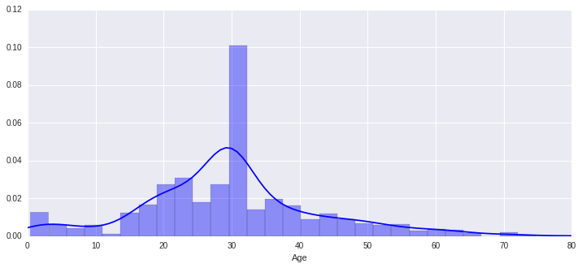

```python
fig, ax = plt.subplots(1, 1, figsize=(12, 5))
ax.axes.set_xlim(0, 80)
g = sns.distplot(df['Age'], color="b", ax=ax)
```

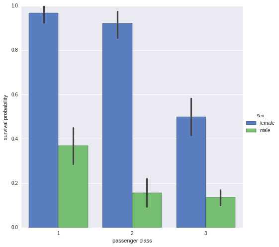

```python
# Draw a nested barplot to show survival for class and sex
g = sns.factorplot(x="Class", y="Alive", hue="Sex", data=df, size=7, kind="bar", palette="muted")
g.set_ylabels("survival probability")
g.set_xlabels("passenger class")
```

## Fitting a simple predictive model

```python
from sklearn.ensemble import RandomForestClassifier
from sklearn.cross_validation import train_test_split

# Define features and target variables
X = df.drop('Alive', axis=1)
y = df['Alive']
# Convert categories to integer values
X['Sex'] = X['Sex'].cat.codes
X['Port'] = X['Port'].cat.codes
# Convert to NumPy arrays
X = X.values
y = y.values
```

```python
# Split the data into train and test sets
X_train, X_test, y_train, y_test = train_test_split(X, y, random_state=0)
```

```python
# Create and train the model
model = RandomForestClassifier(n_estimators = 100, random_state=0)
model.fit(X_train, y_train)
```

```python
# Make some predictions on the test set and compare with the truth
preds = model.predict(X_test)
print("Accuracy: {:.1%}".format(np.mean(preds == y_test)))
```

```
Accuracy: 83.4%
```

# And there is much, much more!

[figure not shown]

## Additional libraries for Data Science

#### Visualisation

- **Bokeh** allows interactive visualization like plots, dashboards in web browsers.
- **Pygal** for standard but sexy charts in SVG.

#### High-performance computing

- **Theano** evaluate mathematical expressions involving multi-dimensional arrays efficiently.
- **Spark** is fast and general-purpose cluster computing system with PySpark as Python interface.
- **Cython** is an optimising static compiler for writing C-extensions in a Python-like language.
- **Dask** enables parallel computing through task scheduling and blocked algorithms (Out-of-Core).
- **TensorFlow** is a library for numerical computation using data flow graphs often used for AI.

#### Miscellaneous

- **scikit-image** provides tools for image processing.
- **SQLAlchemy** is an SQL toolkit and Object Relational Mapper.
- **SymPy** is library for symbolic mathematics, i.e. computer algebra system like Maple.
- **PyMC** features Bayesian statistical models including Markov chain Monte Carlo.
- **NetworkX** for working with structure, dynamics, and functions of complex networks.

# Questions?

[figure not shown]

# Credits

This presentation was inspired by:

- [Savarin's PyCon UK Tutorial](http://nbviewer.jupyter.org/github/savarin/pyconuk-introtutorial/blob/master/notebooks/Section%201-1%20-%20Filling-in%20Missing%20Values.ipynb)
- [Thomas Wiecki's Introduction to Data Analysis with Python](http://nbviewer.jupyter.org/github/twiecki/pydata_ninja/blob/master/PyData%20Ninja.ipynb)
- [Kaggle's Titantic: Machine Learning from Disaster](https://www.kaggle.com/c/titanic/)